# 07. Переносимость портфеля методов GEA на 14 реплик — ADAPTOGENE

MVP × 12 реплик SS-Mtn · 2 плеча Filter.maf · 5 рунгов × 11 методов · перенос схем против поиска заново · 2 контроля Est-Clines досчитываются

## Обзор

Обзор файла: журнал 06 показал на **одной** реплике, что объединение методов бьёт лучший одиночный метод, и что фильтр `Filter.maf: 0.05` превращает непригодные рабочие точки в пригодные. Оба утверждения измерены **на своей выборке**: подмножество методов, помодельные пороги и окно согласия выбраны на тех же каузальных локусах, на которых потом отчитан F1. Журнал 07 переносит фиксированные схемы якоря на реплики, которые не участвовали в их выборе, и отдельно воспроизводит полный поиск на каждой реплике — разница между этими двумя числами и есть смещение отбора.

**Область этой версии файла — 12 реплик `SS-Mtn`, обе плеча.** Две реплики `Est-Clines` (**1231578**, **1232568**) досчитываются и в таблицы не входят. Ни одно утверждение журнала от них не зависит: они и так исключены из каждого кросс-сидового голосования по построению (R²(PC1~temp) **0.92–0.94** — они не выборка из той же популяции сценариев, что `SS-Mtn`). Единственный раздел, которому они нужны, — **12**, проверка фальсифицируемости рамки; он помечен как ожидающий и дописывается пересчётом агрегатора на 14 реплик без каких-либо других изменений.

```bash
if [ ! -f /mnt/data/eugene/ADAPTOGENE/work/journal/diagrams/07_00_abstract.svg ] || \
   [ /mnt/data/eugene/ADAPTOGENE/work/journal/diagrams/07_00_abstract.d2 -nt \
     /mnt/data/eugene/ADAPTOGENE/work/journal/diagrams/07_00_abstract.svg ]; then
  d2 --theme 200 --layout elk \
    /mnt/data/eugene/ADAPTOGENE/work/journal/diagrams/07_00_abstract.d2 \
    /mnt/data/eugene/ADAPTOGENE/work/journal/diagrams/07_00_abstract.svg
fi
```

[figure not shown]

# Часть I. Дизайн

## 1. Что журнал 06 доказал, а что нет

**Утверждение журнала 06:** на реплике `MVP1232548` в плече `Filter.maf: 0.05` объединение бьёт лучший одиночный метод во всех пяти рунгах коррекции структуры, максимум F1 **0.625** (`LFMM+RDA+EMMAX`, `at_least_2`, окно **5** кб), а дефолтный рунг c3 даёт F1 **0.542** при **81** вызове и `precision_strict` **1.000**.

**Чего это утверждение не может обосновать.** Колонка `f1_gain` в `benchmarks/mvp_eval/report06_m05/solo_vs_combine.tsv` — разность двух величин, каждая из которых максимизирована **на той же реплике**, на которой потом отчитана:

- «лучшее объединение» выбрано перебором ≈30 подмножеств × до 27 назначений × 4 окна;
- «лучший одиночный» выбран перебором всей сетки порогов этого метода.

Обе стороны — in-sample, знаменатель — **43** каузальных локуса. Часть разности есть отбор, и никакое число внутри одной реплики не отделяет одно от другого.

**Что делает журнал 07.** Разделяет два семейства чисел и никогда их не усредняет вместе:

| семейство | что фиксировано | что может обосновать |
| --- | --- | --- |
| **перенос** | подмножество, правило, окно (и, в строгом варианте, помодельные пороги) взяты с якоря | «объединение переносится» |
| **поиск заново** | ничего не фиксировано, полный перебор на этой реплике | «вот что рекомендовать для этих данных» |

Схемы переноса перечислены в `/mnt/data/eugene/ADAPTOGENE/benchmarks/mvp_anchor_schemes.tsv`; каждая оценивается в двух режимах:

- `verbatim` — подмножество, правило, окно **и** помодельные рабочие точки якоря без изменений. Строгий тест. Но рабочая точка не является переносимым объектом: `top_100` отбирает 100 SNP и там, где каузальных локусов **43**, и там, где их **395**, поэтому проигрыш `verbatim` на полигенной реплике ожидаем и **не** является свидетельством о структуре объединения.
- `recal` — подмножество, правило и окно якоря, но помодельные точки переизбраны из кандидатного набора **этой** реплики. Изолирует переносимое утверждение (структура комбинации) от непереносимого (калибровка).

Ни один из режимов не выбирает подмножество на этой реплике, поэтому ни один не наследует смещение отбора, которое `*_portfolio.tsv` несёт по построению.

**Базовые линии — две, и они отвечают на разные вопросы:**

- `best_solo_f1` — лучший одиночный метод **после** перебора сетки этой реплики. Сравнение консервативное: in-sample базис против out-of-sample схемы, поэтому любой положительный прирост — нижняя граница.
- `default_solo_f1` — схема `B1`, LFMM при `bonf 0.05`. То, что пользователь получает сегодня одним методом без настройки. Пользовательское сравнение.

```r
check_files(c(
  "/mnt/data/eugene/ADAPTOGENE/benchmarks/mvp_anchor_schemes.tsv",
  "/mnt/data/eugene/ADAPTOGENE/benchmarks/mvp_journal07.sh",
  "/mnt/data/eugene/ADAPTOGENE/benchmarks/mvp_crossseed_report.R",
  "/mnt/data/eugene/ADAPTOGENE/benchmarks/mvp_eval/report06_m05/headline.tsv"))
```

```
## [OK] /mnt/data/eugene/ADAPTOGENE/benchmarks/mvp_anchor_schemes.tsv
## [OK] /mnt/data/eugene/ADAPTOGENE/benchmarks/mvp_journal07.sh
## [OK] /mnt/data/eugene/ADAPTOGENE/benchmarks/mvp_crossseed_report.R
## [OK] /mnt/data/eugene/ADAPTOGENE/benchmarks/mvp_eval/report06_m05/headline.tsv
```

```
## Схемы, перенесённые с якоря MVP1232548:
##
##    scheme_id    подмножество    правило окно_кб
##       <char>          <char>     <char>   <int>
## 1:        S1  LFMM+RDA+EMMAX at_least_2       5
## 2:        S2      LFMM+EMMAX      union       0
## 3:        S3 LFMM+EMMAX+MLMM at_least_2       5
## 4:        S4  LFMM+RDA+EMMAX at_least_2       5
## 5:        S5        LFMM+RDA      union       0
## 6:        S6             ALL at_least_3       5
## 7:        B1            LFMM       solo       0
## 8:        B2             ALL      union       0
##                                     назначение
##                                         <char>
## 1: LFMM:top_100;RDA:top_100;EMMAX:custom_1e-04
## 2:            LFMM:custom_0.001;EMMAX:bonf_0.5
## 3:     LFMM:top_100;EMMAX:qval_0.1;MLMM:top_50
## 4:  LFMM:top_30;RDA:top_100;EMMAX:custom_1e-04
## 5:                      LFMM:top_50;RDA:top_10
## 6:                                 *:bonf_0.05
## 7:                              LFMM:bonf_0.05
## 8:                                 *:bonf_0.05
```

## 2. Потолок top-N: он был конфаундером, и его пришлось сделать посидовым

Журнал 06 §1 прямо называет ограничение `top <= 100` причиной выбора **одной** реплики: на репликах с 268–515 каузальными локусами потолок цензурирует recall по построению, а не по качеству метода. Перенести этот потолок в кросс-сидовое сравнение означало бы измерять потолок.

**Правило, применённое одинаково к обоим плечам одной реплики:**

`TOP_MAX` = наименьшее значение сетки `{100, 200, 500, 1000, 2000, 5000}`, не меньшее **2 × (тестируемых каузальных локусов, базовое плечо)**, с полом **100**.

- Оба плеча одной реплики делят **одно** значение, иначе контраст плеч был бы заодно контрастом сеток: под MAF 0.05 каузальных локусов выживает меньше, поэтому посплечное правило дало бы плечу `m05` систематически более узкую сетку, и часть любого различия между плечами была бы этим различием сеток.
- Значение берётся из **базового** плеча, потому что там каузальных локусов больше, и recall 1.0 остаётся достижим в обоих плечах.
- **Следствие для якоря, которое нужно назвать прямо.** На `MVP1232548` правило даёт **200** (базовое плечо, **70** каузальных), и это значение применяется к обоим его плечам. Журнал 06 скорил плечо `m05` при **100**. Значит журнал 07 **пересчитывает** якорь при 200 (не перепрогоняет — таблицы p-значений те же симлинки), и его таблицы здесь **не совпадают** с опубликованными в журнале 06. Это не потеря воспроизводимости: числа журнала 06 воспроизведены отдельным прогоном при их собственной сетке `top<=100` — раздел 5, — и именно тот прогон является регрессионным гейтом. Таблицы журнала 06 на диске не тронуты.

**Следствие, которое обязано сопровождать любое из этих чисел: абсолютный F1 больше не сравним между репликами.** Сравнимо только внутрисидовое: разность против собственной базовой линии той же реплики, или ранг. Ни одно кросс-сидовое утверждение здесь не является средним от F1.

```r
check_files("/mnt/data/eugene/ADAPTOGENE/benchmarks/mvp_seed_topmax.tsv")
```

```
## [OK] /mnt/data/eugene/ADAPTOGENE/benchmarks/mvp_seed_topmax.tsv
```

```bash
# НЕ ПЕРЕЗАПУСКАТЬ — выполнено 2026-08-03
/mnt/data/eugene/ADAPTOGENE/benchmarks/mvp_journal07.sh configs
```

```
##        seed      архитектура демография k_best r2_pc1_temp каузальных top_max
##      <char>           <char>     <char>  <int>       <num>      <int>   <int>
##  1: 1231578 highly-polygenic Est-Clines      2      0.9197        515    2000
##  2: 1231798 highly-polygenic     SS-Mtn      3      0.3973        395    1000
##  3: 1232923 highly-polygenic     SS-Mtn      3      0.3245        363    1000
##  4: 1233133 highly-polygenic     SS-Mtn      2      0.3103        324    1000
##  5: 1232908 highly-polygenic     SS-Mtn      2      0.3973        268    1000
##  6: 1232548    mod-polygenic     SS-Mtn      5      0.5726         70     200
##  7: 1231858    mod-polygenic     SS-Mtn      3      0.5206         46     100
##  8: 1233208    mod-polygenic     SS-Mtn      4      0.4506         39     100
##  9: 1232568    mod-polygenic Est-Clines      2      0.9397         38     100
## 10: 1232578    mod-polygenic     SS-Mtn      7      0.4333         28     100
## 11: 1232398        oliogenic     SS-Mtn      2      0.5026         10     100
## 12: 1231993        oliogenic     SS-Mtn      2      0.4180          8     100
## 13: 1231288        oliogenic     SS-Mtn      2      0.5712          6     100
## 14: 1232218        oliogenic     SS-Mtn      2      0.3450          6     100
```

## 3. Конфиги: 13 реплик × 2 плеча, один манифест на плечо

`/mnt/data/eugene/ADAPTOGENE/benchmarks/mvp_journal07.sh` — новый драйвер. Развернуть `mvp_journal06.sh` по сидам было бы неверно **молча**, в трёх местах:

1. **Манифест ячеек не содержит сида в имени.** `mvp_journal06.sh` выводит `CELLS_TSV="benchmarks/mvp_sweep_cells_p11${ARM_TAG}.tsv"`. Параллельные посидовые вызовы `mvp_write_sweep_configs.R` затирали бы один и тот же файл, а `mvp_score_sweep.sh` потом читал бы то, что выиграло гонку. Здесь генерация конфигов — **отдельная стадия**, один вызов на плечо, покрывающий все сиды; стадии прогона и скоринга манифест не пишут вовсе.
2. **`TOP_MAX` посидовый** (раздел 2), берётся из `benchmarks/mvp_seed_topmax.tsv`, а не из константы.
3. **Якорь не перепрогоняется.** `params07{,_m05}/MVP1232548{,M05}` — симлинки в сборку журнала 06. Перепрогон сдвинул бы ту самую опорную точку, к которой всё привязано.

Ресурсная рамка: хост общий (в момент запуска другие задачи держали ≈**300** ГБ и load ≈**120**), грант пользователя — **120** CPU / **600** ГБ. Замеренный пик одной 11-методной реплики в журнале 06 — **81** ГБ (`benchmarks/mvp_eval/c1_memtrace.txt`), поэтому **5** одновременных реплик по `--cpus=24 --memory=110g`. `BLAS_THREADS=16` — то же значение, что в журналах 05 и 06: без пина контейнер видит 192 ядра хоста, OpenBLAS буксует (в 40 раз медленнее, 81 ГБ), а число потоков переставляет порядок суммирования с плавающей точкой, поэтому смешивать значения внутри одного бенчмарка нельзя.

Отличие конфига плеча `m05` от базового — по-прежнему ровно **две** строки: `project_name` и `Filter.maf`. `Input.*` побайтово совпадает.

```r
check_files(c(
  "/mnt/data/eugene/ADAPTOGENE/benchmarks/mvp_sweep_cells_j07.tsv",
  "/mnt/data/eugene/ADAPTOGENE/benchmarks/mvp_sweep_cells_j07_m05.tsv",
  "/mnt/data/eugene/ADAPTOGENE/config_MVP1232568_c3_p11.yaml",
  "/mnt/data/eugene/ADAPTOGENE/config_MVP1232568M05_c3_p11.yaml"))
```

```
## [OK] /mnt/data/eugene/ADAPTOGENE/benchmarks/mvp_sweep_cells_j07.tsv
## [OK] /mnt/data/eugene/ADAPTOGENE/benchmarks/mvp_sweep_cells_j07_m05.tsv
## [OK] /mnt/data/eugene/ADAPTOGENE/config_MVP1232568_c3_p11.yaml
## [OK] /mnt/data/eugene/ADAPTOGENE/config_MVP1232568M05_c3_p11.yaml
```

```bash
# НЕ ПЕРЕЗАПУСКАТЬ — выполнено 2026-08-03
# Гейт на конфиг: единственные отличия плеча — project_name и Filter.maf.
diff /mnt/data/eugene/ADAPTOGENE/config_MVP1232568_c3_p11.yaml \
     /mnt/data/eugene/ADAPTOGENE/config_MVP1232568M05_c3_p11.yaml
# 26c26
# < project_name: MVP1232568
# ---
# > project_name: MVP1232568M05                 # parallel arm of MVP1232568
# 39c39
# <   maf: 0.01
# ---
# >   maf: 0.05                                  # arm override
```

- Конфигов записано: **13** сидов × **5** ячеек × **2** плеча = **130**
- Строк манифеста: **715** на плечо (13 сидов × 5 ячеек × 11 методов)
- Отличие плеч на конфиг: **2** строки

## 4. Два дефекта харнесса, найденные этим прогоном

**4.1. Проверка завершённости смотрела на чужое плечо.** Найдено при подготовке многосидового прогона, исправлено до запуска.

`benchmarks/mvp_run_sweep.sh` в финальной проверке грепал `MVP${seed}.log` — **без** `PROJ_SUFFIX`. Функция `run_seed` пишет в `MVP{seed}{PROJ_SUFFIX}.log`, поэтому на параллельном плече проверялся лог **базового** плеча, который после его прогона всегда содержит `DONE`. Плечо `m05` могло упасть на каждом сиде, и цикл всё равно отчитался бы «all seeds complete».

В журнале 06 дефект не проявился: там плечо `m05` запускалось по одному сиду, и ложное «ОК» совпало с настоящим.

**4.2. Сбор урожая копировал устаревшую таблицу исключённого метода.** Найдено уже во время прогона — гейтом самого харнесса, а не глазами.

`mvp_method_exclusions.tsv` читается на этапе **генерации конфигов**: объявленный метод выбрасывается из `GEA.configs`, поэтому `mode=gea` его больше не считает. Но таблица от **предыдущего** прогона остаётся лежать в `{PROJECT}_results/GEA/tables/methods/{METHOD}/`, а проверка исключения в цикле сбора стояла **внутри** ветки «файла нет». Порядок был такой: файл есть (устаревший) → исключение не проверяется → файл копируется в ячейку. И так в каждую ячейку лестницы, один и тот же файл.

Поймал это гейт побайтового сравнения: «c2 SUPER byte-identical to the previous cell — the parameter did not take effect. Ladder would be a fiction; aborting». Он ровно для этого и написан. На остальных репликах SUPER между c4 и c5 отличается нормально — проверено явно.

Правка: проверять исключение **до** теста на существование файла, тогда исключённый метод не собирается вовсе. Плюс устаревшие таблицы `MLMM`/`SUPER` удалены из затронутых проектов.

```bash
# НЕ ПЕРЕЗАПУСКАТЬ — выполнено 2026-08-03 / 2026-08-04
# Правка 1: benchmarks/mvp_run_sweep.sh, финальный цикл проверки
#   [изменено 2026-08-03] было:  grep -q "^\[MVP${seed}\] DONE" "$RUNLOG_DIR/MVP${seed}.log"
#                         стало: proj="MVP${seed}${PROJ_SUFFIX}"
#                                grep -q "^\[${proj}\] DONE" "$RUNLOG_DIR/${proj}.log"
#
# Правка 2: benchmarks/mvp_run_sweep.sh, цикл сбора урожая
#   [изменено 2026-08-04] было:  if [[ ! -s "$src" ]]; then <проверка исключения>; FATAL; fi
#                                cp "$src" ...
#                         стало: <проверка исключения> -> continue
#                                if [[ ! -s "$src" ]]; then FATAL; fi
#                                cp "$src" ...
# Подтверждение, что гейт ловил настоящее, а не ложное срабатывание:
#   cmp params07/MVP1232568/c4/SUPER_pvalues.tsv params07/MVP1232568/c5/SUPER_pvalues.tsv  -> identical
#   cmp params07/MVP1231288/c4/SUPER_pvalues.tsv params07/MVP1231288/c5/SUPER_pvalues.tsv  -> differ
```

**Примечание — паритет наборов методов между плечами**

Реактивные объявления исключений создали побочный эффект: реплика могла завершить одно плечо **до**, а другое **после** объявления, и тогда её плечи несли разные наборы методов (`1231578` 9 против 11, `1232568` 11 против 9, `1231993` 10 против 11). Для парного сравнения плеч это недопустимо — поиск подмножеств тянул бы из разных пулов. Наборы выровнены, и в харнесс добавлен явный **гейт паритета**: перед скорингом наборы методов каждой реплики сравниваются между плечами, любое расхождение печатается. Итоговый паритет по 12 репликам — 11 методов везде, кроме `1231993` (**10**, `MLMM` исключён на обоих плечах).

## 5. Перенос схем: флаг `--schemes` в `sweep_portfolio.R`

Оценка фиксированной схемы требует ровно той же машинерии объединения, что и поиск (`combine_support` + `score_calls`), поэтому она добавлена **в тот же скрипт**, а не продублирована в новом. `sweep_portfolio.R` получил необязательный флаг `--schemes=FILE`:

- без флага поведение и вывод не меняются — `{TAG}_portfolio.tsv` побайтово прежний;
- с флагом дополнительно пишется `{TAG}_transfer.tsv`, по две строки на схему (`verbatim` и `recal`).

Разбор рабочей точки делит строку `<adjust>_<value>` по **первому** подчёркиванию — иначе `custom_1e-04` теряет экспоненту. Токен `*:bonf_0.05` в назначении означает «все методы подмножества в этой точке» и нужен для схем `S6`/`B2`, где подмножество — все 11 методов.

Режим `recal` перебирает кандидатные точки этой реплики по тому же правилу, что и основной поиск: полное произведение для ≤ 3 методов, три **когерентных** ролевых назначения при большем размере (все методы в лучшей по F1 точке / все в высокоточной / все на дефолте пайплайна).

```r
check_files(c(
  "/mnt/data/eugene/ADAPTOGENE/benchmarks/sweep_portfolio.R",
  "/mnt/data/eugene/ADAPTOGENE/benchmarks/mvp_eval/_j07test/MVP1232548M05_c4_any_transfer.tsv"))
```

```
## [OK] /mnt/data/eugene/ADAPTOGENE/benchmarks/sweep_portfolio.R
## [OK] /mnt/data/eugene/ADAPTOGENE/benchmarks/mvp_eval/_j07test/MVP1232548M05_c4_any_transfer.tsv
```

```bash
# НЕ ПЕРЕЗАПУСКАТЬ — выполнено 2026-08-03
# Гейт: тот же вызов, что журнал 06, ПЛЮС --schemes; portfolio/candidates должны совпасть.
cmp /mnt/data/eugene/ADAPTOGENE/benchmarks/mvp_eval/portfolio_m05/MVP1232548M05_c4_any_portfolio.tsv \
    /mnt/data/eugene/ADAPTOGENE/benchmarks/mvp_eval/_j07test/MVP1232548M05_c4_any_portfolio.tsv
cmp /mnt/data/eugene/ADAPTOGENE/benchmarks/mvp_eval/portfolio_m05/MVP1232548M05_c4_any_candidates.tsv \
    /mnt/data/eugene/ADAPTOGENE/benchmarks/mvp_eval/_j07test/MVP1232548M05_c4_any_candidates.tsv
```

```
## Схемы, оценённые на самом якоре (ячейка c4, плечо MAF 0.05) — самопроверка:
##
##     scheme_id    режим вызовов    tp precision recall    f1
##        <char>   <char>   <int> <int>     <num>  <num> <num>
##  1:        S1 verbatim     173    20     0.952  0.465 0.625
##  2:        S1    recal     173    20     0.952  0.465 0.625
##  3:        S2 verbatim      79    14     0.824  0.326 0.467
##  4:        S2    recal     184    20     0.606  0.465 0.526
##  5:        S3 verbatim     165    16     0.552  0.372 0.444
##  6:        S3    recal     165    16     0.552  0.372 0.444
##  7:        S4 verbatim      73    14     1.000  0.326 0.491
##  8:        S4    recal     173    20     0.952  0.465 0.625
##  9:        S5 verbatim      96    16     0.727  0.372 0.492
## 10:        S5    recal     184    20     0.606  0.465 0.526
## 11:        S6 verbatim      60     9     0.529  0.209 0.300
## 12:        S6    recal      69    10     0.556  0.233 0.328
## 13:        B1 verbatim      21     6     1.000  0.140 0.245
## 14:        B1    recal     184    20     0.606  0.465 0.526
## 15:        B2 verbatim     115    13     0.342  0.302 0.321
## 16:        B2    recal     145    18     0.409  0.419 0.414
```

- `S1` `verbatim` на якоре: **173** вызова, **20** TP, precision **0.952**, F1 **0.625** — побайтово те же числа, что в `report06_m05/headline.tsv`
- `_portfolio.tsv` и `_candidates.tsv` с флагом и без него — **идентичны**
- `B1` (LFMM при `bonf 0.05`, дефолт пайплайна одним методом) на якоре: F1 **0.245**
- `B2` (все 11 методов, `union`, `bonf 0.05` — то, что `mode=gea` делает сегодня): F1 **0.321**

# Часть II. Прогон

## 6. Лестницы: 26 прогонов

`mvp_journal07.sh run base` и затем `run m05`. Внутри каждого плеча — **13** реплик по **5** одновременно, каждая: `processing` → `prestructure` → `structure` → `pregea` → 5 ячеек `mode=gea` с 11 методами и сбором таблиц WZA.

Базовое плечо переиспользует upstream, посчитанный журналом 05, поэтому стартует сразу с ячеек; плечо `m05` — отдельный `project_name`, поэтому считает upstream заново.

Гейты внутри `mvp_run_sweep.sh`, сохранённые без изменений: отсутствующая таблица p-значений фатальна, если пара (сид, метод) не объявлена в `mvp_method_exclusions.tsv`; побайтово совпавшая с предыдущей ячейкой таблица фатальна (рунг не применился); Manhattan старше начала ячейки фатален (фигура не соответствует p-значениям).

```r
check_files(c(
  "/mnt/data/eugene/ADAPTOGENE/benchmarks/mvp_eval/journal07_run_base.log",
  "/mnt/data/eugene/ADAPTOGENE/benchmarks/mvp_eval/journal07_run_m05.log"))
```

```
## [OK] /mnt/data/eugene/ADAPTOGENE/benchmarks/mvp_eval/journal07_run_base.log
## [OK] /mnt/data/eugene/ADAPTOGENE/benchmarks/mvp_eval/journal07_run_m05.log
```

```bash
# НЕ ПЕРЕЗАПУСКАТЬ — выполнено 2026-08-03
/mnt/data/eugene/ADAPTOGENE/benchmarks/mvp_journal07.sh run base \
  > /mnt/data/eugene/ADAPTOGENE/benchmarks/mvp_eval/journal07_run_base.log 2>&1
/mnt/data/eugene/ADAPTOGENE/benchmarks/mvp_journal07.sh run m05 \
  > /mnt/data/eugene/ADAPTOGENE/benchmarks/mvp_eval/journal07_run_m05.log 2>&1
```

```
##
## Плечо MAF 0.01:
##         проект состояние
##         <char>    <char>
##  1: MVP1231288      DONE
##  2: MVP1231578      DONE
##  3: MVP1231798      DONE
##  4: MVP1231858      DONE
##  5: MVP1231993      DONE
##  6: MVP1232218      DONE
##  7: MVP1232398      DONE
##  8: MVP1232568      DONE
##  9: MVP1232578      DONE
## 10: MVP1232908      DONE
## 11: MVP1232923      DONE
```

[output cut: 19 more lines]

## 7. Таблицы истины под MAF для 13 реплик

`benchmarks/mvp_filter_truth_maf.R`, по одному вызову на реплику, **после** прогона плеча `m05` — набор SNP берётся из настоящего отфильтрованного VCF пайплайна (`{PROJ}_results/_work/maf0.05_*/MVP{seed}.vcf`), а не пересчитывается по `loci_freq.tsv`: `--maf` в plink исключает варианты **ниже** порога, то есть сохраняет `MAF >= 0.05`, и на якоре ровно **18** SNP стоят на самой границе, один из них каузальный.

Из таблицы истины выбрасывается **каждая** строка, чей SNP не переживает фильтр — `causal`, `linked_neutral` и `background_neutral` одинаково. Скоринг отфильтрованного VCF против неотфильтрованной истины делил бы recall на локусы, которых в VCF уже нет; это ровно тот дефект, который дисквалифицировал бенчмарк Láruson.

```bash
# НЕ ПЕРЕЗАПУСКАТЬ — выполнено 2026-08-03
/mnt/data/eugene/ADAPTOGENE/benchmarks/mvp_journal07.sh truth
```

```
##         сид SNP_до SNP_после каузальных_до каузальных_после
##      <char>  <int>     <int>         <int>            <int>
##  1: 1231288  11194      9026             6                6
##  2: 1231578  13054     10060           515              244
##  3: 1231798   9867      7344           395              195
##  4: 1231858   8482      6418            46               25
##  5: 1231993   4975      3310             8                6
##  6: 1232218   9882      7167             6                5
##  7: 1232398   9498      7149            10                9
##  8: 1232548  10325      7841            70               43
##  9: 1232568  10019      7666            38               23
## 10: 1232578  10072      7658            28               18
## 11: 1232908  11353      8904           268              125
## 12: 1232923  12095      9715           363              185
## 13: 1233133  10756      8184           324              151
```

[output cut: 17 more lines]

# Часть III. Результаты

## 8. Переносится ли выигрыш от объединения

`benchmarks/mvp_crossseed_report.R`. Агрегация идёт **сначала внутри реплики** (медиана по пяти рунгам), и только потом по репликам — иначе реплика, у которой лестница дала больше пригодных ячеек, перевесила бы ту, у которой их меньше.

Из голосования исключены:

- **два контроля `Est-Clines`** (`1232568`, `1231578`) — R²(PC1~temp) **0.92–0.94**, структура и предиктор там почти одна и та же переменная. Они не являются выборкой из той же популяции сценариев, что реплики `SS-Mtn`; их роль — раздел 12.
- **реплики с < 15 каузальными локусами** (`1231288`, `1232218`, `1231993`, `1232398`) — один локус двигает F1 сильнее, чем сравниваемые различия. Они помечены и показаны, но не голосуют.

```r
check_files(c(
  paste0(R7, "transfer.tsv"),
  paste0(R7, "transfer_summary.tsv"),
  paste0(R7, "transfer_by_arch.tsv"),
  paste0(R7, "recommended_schemes.tsv")))
```

```
## [OK] /mnt/data/eugene/ADAPTOGENE/benchmarks/mvp_eval/report07/transfer.tsv
## [OK] /mnt/data/eugene/ADAPTOGENE/benchmarks/mvp_eval/report07/transfer_summary.tsv
## [OK] /mnt/data/eugene/ADAPTOGENE/benchmarks/mvp_eval/report07/transfer_by_arch.tsv
## [OK] /mnt/data/eugene/ADAPTOGENE/benchmarks/mvp_eval/report07/recommended_schemes.tsv
```

```bash
# НЕ ПЕРЕЗАПУСКАТЬ — выполнено 2026-08-03
/mnt/data/eugene/ADAPTOGENE/benchmarks/mvp_journal07.sh score base
/mnt/data/eugene/ADAPTOGENE/benchmarks/mvp_journal07.sh score m05
/mnt/data/eugene/ADAPTOGENE/benchmarks/mvp_journal07.sh aggregate
```

```
## Схемы якоря, перенесённые на реплики, которые не участвовали в их выборе
## (медиана по рунгам внутри реплики, затем по репликам; контроли и слабомощные исключены):
##
##      плечо schema реплик бьёт_дефолт бьёт_лучший_одиночный прирост_к_дефолту
##     <char> <char>  <int>       <int>                 <int>             <num>
##  1:   base     S2      8           8                     0            0.1603
##  2:   base     S1      8           8                     3            0.1553
##  3:   base     S4      8           8                     3            0.1553
##  4:   base     S5      8           8                     1            0.1513
##  5:   base     S3      8           8                     1            0.1491
##  6:   base     B2      8           5                     0            0.0709
##  7:   base     S6      8           7                     1            0.0573
##  8:    m05     S1      8           8                     4            0.2160
##  9:    m05     S4      8           8                     4            0.2160
## 10:    m05     S5      8           8                     1            0.2105
```

[output cut: 39 more lines]

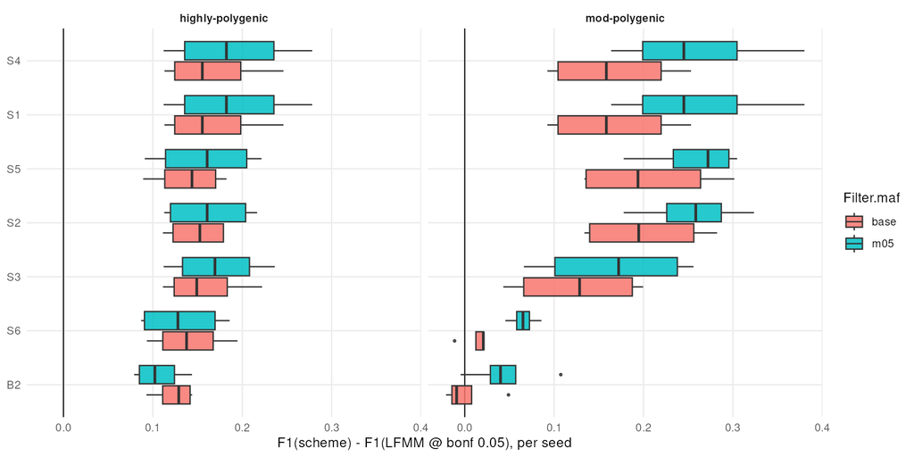

**Голосующих реплик — 8** (12 минус 4 слабомощных; контроли не входили изначально). Медиана берётся сначала по 5 рунгам внутри реплики, затем по репликам.

**Плечо `Filter.maf: 0.05`, режим `recal`:**

| схема | бьёт дефолт | бьёт лучший одиночный | прирост к дефолту | прирост к лучшему одиночному | F1 | вызовов |
| --- | --- | --- | --- | --- | --- | --- |
| `S1`/`S4` LFMM+RDA+EMMAX, `at_least_2` @5 кб | **8/8** | **4/8** | **+0.216** | **+0.005** | **0.296** | **277** |
| `S5` LFMM+RDA, `union` | **8/8** | 1/8 | +0.211 | 0.000 | 0.281 | 288 |
| `S2` LFMM+EMMAX, `union` | **8/8** | 3/8 | +0.208 | 0.000 | **0.298** | 288 |
| `S3` LFMM+EMMAX+MLMM, `at_least_2` @5 кб | 8/8 | 2/8 | +0.169 | −0.031 | 0.230 | 375 |
| `S6` все 11, `at_least_3` @5 кб | 8/8 | **0/8** | +0.086 | −0.071 | 0.201 | 533 |
| `B2` все 11, `union`, `bonf 0.05` — **дефолт пайплайна сегодня** | 7/8 | **0/8** | +0.083 | **−0.122** | 0.166 | **1 242** |

**Плечо `Filter.maf: 0.01`** — тот же порядок схем, приросты меньше: **+0.149 … +0.160** к дефолту, F1 **0.193 … 0.233**.

Утверждение журнала 06 «объединение бьёт лучший одиночный метод» **не переносится** в той форме, в какой оно там сформулировано. Переносится более слабое и более полезное:

**объединение надёжно бьёт то, что пользователь получает, ничего не настраивая, — но не бьёт хорошо настроенный одиночный метод.**

Разрыв между этими двумя утверждениями и есть то, что journal 06 не мог увидеть на одной реплике: там «лучший одиночный» тоже выбирался поиском по той же реплике, поэтому обе стороны сравнения были одинаково перетюнены, и разность выглядела свойством объединения.

Практическое следствие для пайплайна прямое: **`B2` — то, что `mode=gea` делает сегодня (`SIGSNPS_METHOD = 'All'`, объединение при `bonf 0.05`) — худшая из проверенных схем.** Она вызывает медианно **1 242** SNP и проигрывает настроенному одиночному методу на всех восьми репликах. Замена её на `LFMM+RDA+EMMAX` при `at_least_2` в окне 5 кб даёт **+0.13** F1 при **4.5×** меньшем числе вызовов.

## 9. Смещение отбора: сколько стоит поиск на своей реплике

Смещение = (лучшая комбинация, **найденная** перебором на этой реплике) − (лучшая схема **якоря**, перекалиброванная на этой реплике). Обе стороны — комбинации, обе используют калибровку этой реплики; отличается только то, выбрано ли подмножество/правило/окно **здесь** или импортировано. Значит разность — это то, что купил перебор, и ровно на столько headline журнала 06 завышен как утверждение об общности.

```r
check_files(c(paste0(R7, "selection_bias.tsv"), paste0(R7, "research.tsv")))
```

```
## [OK] /mnt/data/eugene/ADAPTOGENE/benchmarks/mvp_eval/report07/selection_bias.tsv
## [OK] /mnt/data/eugene/ADAPTOGENE/benchmarks/mvp_eval/report07/research.tsv
```

```
## Смещение отбора по стратам (только не-контроли, достаточной мощности):
##
##     плечо      архитектура медиана    q25    q75 ячеек
##    <char>           <char>   <num>  <num>  <num> <int>
## 1:   base highly-polygenic  0.0168 0.0064 0.0462    20
## 2:   base    mod-polygenic  0.0226 0.0000 0.0746    20
## 3:    m05 highly-polygenic  0.0212 0.0092 0.0576    20
## 4:    m05    mod-polygenic  0.0000 0.0000 0.0287    20
```

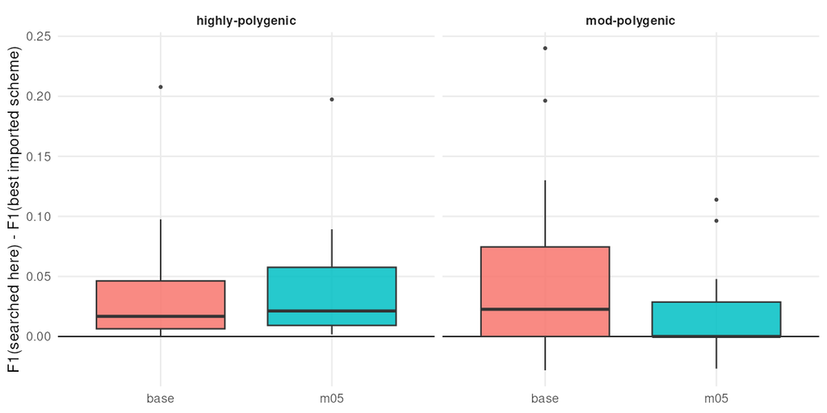

- Медианное смещение: **+0.017** (MAF 0.01), **+0.011** (MAF 0.05) по 40 ячейкам на плечо
- p75: **+0.060** / **+0.045**; максимум: **+0.240** / **+0.197**
- То есть импортированная схема в половине ячеек уступает найденной здесь **менее чем на 0.02** F1

**Смещение отбора мало.** Полный поиск подмножества, назначения и окна на своей реплике покупает медианно **0.011–0.017** F1 сверх схемы, взятой с чужой реплики и лишь перекалиброванной. Для сравнения, разрыв между лучшей схемой и дефолтом пайплайна — **0.22**, то есть на порядок больше.

Два следствия. Во-первых, headline журнала 06 **не** был сильно раздут отбором — конкретное число там завышено на величину этого порядка, но вывод «объединение помогает» держится. Во-вторых, и это важнее для пользователя: **перебирать подмножества на своих данных почти не нужно.** Достаточно взять готовую структуру комбинации и настроить пороги — что и делает `mode=pregea`, не требуя таблицы истины.

Хвост при этом есть: максимум **0.24** означает, что на отдельной реплике поиск всё же может дать много. Медиана — рекомендация, не гарантия.

```
##
## Что выигрывает при полном поиске на каждой реплике (дефолтный рунг c3):
##
##      плечо     сид      архитектура       подмножество      правило  окно
##     <char>   <int>           <char>             <char>       <char> <num>
##  1:   base 1231798 highly-polygenic   LFMM+SUPER+EMMAX intersection   5.0
##  2:   base 1232908 highly-polygenic    SUPER+EMMAX+MLM     rank_sum    NA
##  3:   base 1232923 highly-polygenic     LFMM+EMMAX+RDA intersection   5.0
##  4:   base 1233133 highly-polygenic   BLINK+SUPER+LFMM intersection   1.0
##  5:   base 1231858    mod-polygenic         LFMM+SUPER intersection   2.5
##  6:   base 1232548    mod-polygenic   LFMM+RDA+FarmCPU   at_least_2   1.0
##  7:   base 1232578    mod-polygenic           LFMM+GLM        union   0.0
##  8:   base 1233208    mod-polygenic   SUPER+BLINK+MLMM intersection   5.0
##  9:   base 1231288        oliogenic          LFMM+MLMM     rank_sum    NA
## 10:   base 1231993        oliogenic   EMMAX+LFMM+BLINK   at_least_2   5.0
```

[output cut: 44 more lines]

Журнал 06 нашёл на **одной** реплике, что фильтр MAF 0.05 стоит 5 обнаружимых локусов из 70 и взамен убирает шум, делавший рабочие точки непригодными, и что AUC-PR при этом вырос у всех одиннадцати методов. Доля каузальных локусов ниже MAF 0.05 (**27/70**) — свойство спектра частот именно той симуляции, поэтому утверждение требовало проверки на других спектрах.

Что сравнивается и что сравнивать нельзя:

- **Сравнимо**: precision, `calls_per_tp`, форма компромисса, ранжирование методов, AUC-PR.
- **Не сравнимо напрямую**: абсолютный recall — знаменатели разные по построению.
- **Порог Бонферрони сдвигается механически**: `bonf` = value / n_tested, и `n_tested` падает, то есть порог становится мягче при том же номинальном уровне. Поэтому решающая величина здесь — **AUC-PR**, беспороговая, которую сдвиг знаменателя объяснить не может.

```r
check_files(c(paste0(R7, "arm_compare.tsv"), paste0(R7, "aucpr_by_arm.tsv"),
              paste0(R7, "method_rank.tsv")))
```

```
## [OK] /mnt/data/eugene/ADAPTOGENE/benchmarks/mvp_eval/report07/arm_compare.tsv
## [OK] /mnt/data/eugene/ADAPTOGENE/benchmarks/mvp_eval/report07/aucpr_by_arm.tsv
## [OK] /mnt/data/eugene/ADAPTOGENE/benchmarks/mvp_eval/report07/method_rank.tsv
```

```
## Отношение AUC-PR (плечо 0.05 / плечо 0.01), медиана по репликам, ячейка c3:
##
##       метод медиана_отношения реплик_с_ростом реплик
##      <char>             <num>           <int>  <int>
##  1:    LFMM             1.281              11     12
##  2:     RDA             1.182               9     12
##  3:   SUPER             1.174              10     12
##  4:     GLM             1.172               8     12
##  5:   ECMLM             1.089               9     12
##  6:   EMMAX             1.089               9     12
##  7:     MLM             1.089               9     12
##  8:    MLMM             1.062               7     11
##  9:   BLINK             1.049               8     12
## 10: FarmCPU             1.002               6     12
## 11:    CMLM             0.992               6     12
```

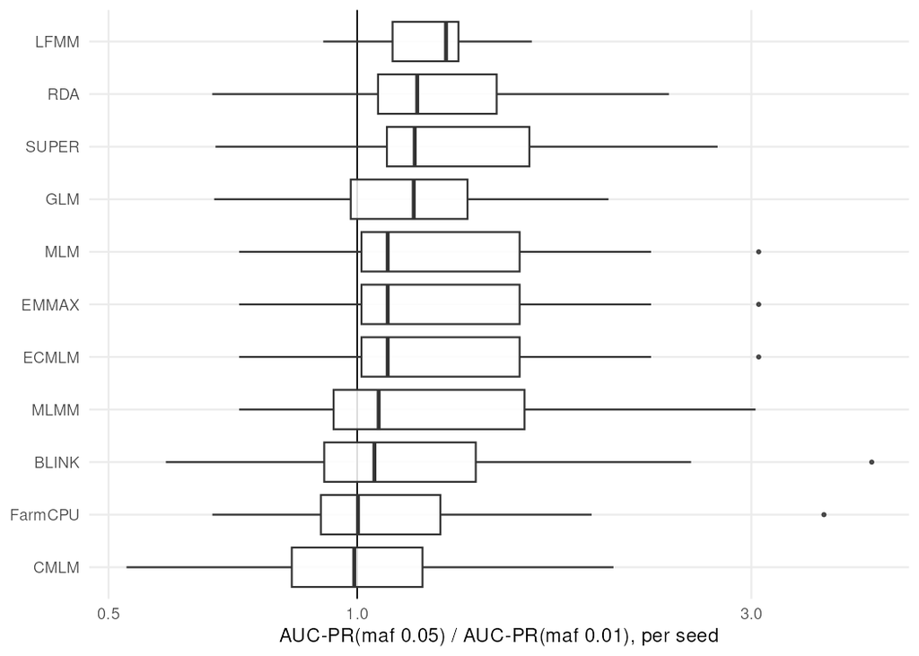

```
##
## Парный контраст плеч по репликам (дефолтный рунг c3), лучшая комбинация каждой:
##
##         сид      архитектура контроль f1_maf01 f1_maf05   d_f1 prec_maf01
##       <int>           <char>   <lgcl>    <num>    <num>  <num>      <num>
##  1: 1231798 highly-polygenic    FALSE    0.410    0.286 -0.124      0.610
##  2: 1232908 highly-polygenic    FALSE    0.119    0.129  0.010      0.091
##  3: 1232923 highly-polygenic    FALSE    0.291    0.349  0.058      0.774
##  4: 1233133 highly-polygenic    FALSE    0.141    0.116 -0.026      0.087
##  5: 1231858    mod-polygenic    FALSE    0.327    0.417  0.089      1.000
##  6: 1232548    mod-polygenic    FALSE    0.415    0.542  0.127      0.611
##  7: 1232578    mod-polygenic    FALSE    0.612    0.727  0.115      0.714
##  8: 1233208    mod-polygenic    FALSE    0.375    0.364 -0.011      1.000
##  9: 1231288        oliogenic    FALSE    0.909    0.909  0.000      1.000
## 10: 1231993        oliogenic    FALSE    1.000    1.000  0.000      1.000
```

[output cut: 16 more lines]

**AUC-PR, отношение плечо 0.05 / плечо 0.01**, по **131** паре (метод × реплика), ячейка c3:

| метод | медиана отношения | реплик с ростом |
| --- | --- | --- |
| LFMM | **1.281** | **11/12** |
| RDA | 1.182 | 9/12 |
| SUPER | 1.174 | 10/12 |
| GLM | 1.172 | 8/12 |
| EMMAX / MLM / ECMLM | 1.089 | 9/12 |
| MLMM | 1.062 | 7/11 |
| BLINK | 1.049 | 8/12 |
| FarmCPU | 1.002 | 6/12 |
| CMLM | **0.992** | 6/12 |

- Общая медиана: **1.11**; доля пар с ростом: **70%**
- Приросты схем к дефолту в плече 0.05 выше, чем в 0.01, у **каждой** схемы: **+0.21–0.22** против **+0.15–0.16**
- Медианный F1 лучших схем: **0.30** против **0.23**

Это ровно то ограничение, которое журнал 06 сам себе и выписал: доля каузальных локусов ниже MAF 0.05 (**27/70**) — свойство спектра частот конкретной симуляции. Проверяемое утверждение формулируется так: **фильтр помогает почти всегда и заметно, но насколько — зависит от того, сколько каузальных локусов сидит в низких частотах именно у этих данных.**

```
##
## Ранг метода по медианному AUC-PR через все реплики:
##
## Key: <method>
##      method rank_base rank_m05 med_aucpr_base med_aucpr_m05
##      <char>     <int>    <int>          <num>         <num>
##  1:   BLINK         6        8      0.1092771    0.17143492
##  2:    CMLM        11       11      0.0787801    0.06859577
##  3:   ECMLM         7        4      0.1043441    0.19912000
##  4:   EMMAX         9        6      0.1043439    0.19911872
##  5: FarmCPU         5        9      0.1105182    0.16471740
##  6:     GLM         3        7      0.1465005    0.19293879
##  7:    LFMM         1        1      0.2647189    0.42193989
##  8:     MLM         7        4      0.1043441    0.19912000
##  9:    MLMM        10       10      0.0998782    0.14134120
## 10:     RDA         4        2      0.1386231    0.21304579
## 11:   SUPER         2        3      0.1472439    0.20736537
```

## 11. Рекомендации по стратам архитектуры

Задача была сформулирована так: не одна универсальная схема, а **несколько наиболее перспективных**, каждая — для своего типа данных. Таблица ниже — три лучшие переносимые схемы (режим `recal`) на каждую страту архитектуры и каждое плечо, ранжированные по медианному приросту к пользовательскому дефолту (LFMM при `bonf 0.05`).

Читать её нужно как «структура комбинации, которую стоит попробовать первой», а не как готовый конфиг: помодельные пороги в режиме `recal` подобраны на самой реплике, и на новых данных их придётся подобрать заново — для этого в пайплайне и существует `mode=pregea`.

```
##          архитектура  плечо  схема                                описание
##               <char> <char> <char>                                  <char>
##  1: highly-polygenic   base     S1         LFMM+RDA+EMMAX, at_least_2, 5kb
##  2: highly-polygenic   base     S4 LFMM+RDA+EMMAX, at_least_2, 5kb, capped
##  3: highly-polygenic   base     S2                  LFMM+EMMAX, union, 0kb
##  4: highly-polygenic    m05     S1         LFMM+RDA+EMMAX, at_least_2, 5kb
##  5: highly-polygenic    m05     S4 LFMM+RDA+EMMAX, at_least_2, 5kb, capped
##  6: highly-polygenic    m05     S3        LFMM+EMMAX+MLMM, at_least_2, 5kb
##  7:    mod-polygenic   base     S2                  LFMM+EMMAX, union, 0kb
##  8:    mod-polygenic   base     S5                    LFMM+RDA, union, 0kb
##  9:    mod-polygenic   base     S1         LFMM+RDA+EMMAX, at_least_2, 5kb
## 10:    mod-polygenic    m05     S5                    LFMM+RDA, union, 0kb
## 11:    mod-polygenic    m05     S2                  LFMM+EMMAX, union, 0kb
## 12:    mod-polygenic    m05     S1         LFMM+RDA+EMMAX, at_least_2, 5kb
##     реплик бьёт_дефолт прирост     f1
##      <int>       <int>   <num>  <num>
##  1:      4           4  0.1553 0.1633
##  2:      4           4  0.1553 0.1633
##  3:      4           4  0.1526 0.1526
##  4:      4           4  0.1823 0.1925
##  5:      4           4  0.1823 0.1925
##  6:      4           4  0.1694 0.1814
##  7:      4           4  0.1947 0.3280
##  8:      4           4  0.1938 0.3304
##  9:      4           4  0.1585 0.3157
## 10:      4           4  0.2722 0.4627
## 11:      4           4  0.2585 0.4690
## 12:      4           4  0.2452 0.4628
```

**Рекомендация зависит от архитектуры признака, и различие устойчиво по плечам:**

| страта | плечо | схема №1 | прирост | схема №2 |
| --- | --- | --- | --- | --- |
| **mod-polygenic** (28–70 каузальных) | MAF 0.05 | **`S5` LFMM+RDA, `union`** | **+0.272** | `S2` LFMM+EMMAX, `union` (+0.259) |
| **mod-polygenic** | MAF 0.01 | `S2` LFMM+EMMAX, `union` | +0.195 | `S5` LFMM+RDA, `union` (+0.194) |
| **highly-polygenic** (268–395) | MAF 0.05 | **`S1` LFMM+RDA+EMMAX, `at_least_2` @5 кб** | **+0.182** | `S3` (+0.169) |
| **highly-polygenic** | MAF 0.01 | `S1` LFMM+RDA+EMMAX, `at_least_2` @5 кб | +0.155 | `S2` LFMM+EMMAX, `union` (+0.153) |

- Каждая рекомендация выигрывает на **4/4** репликах своей страты
- **Олигогенная страта рекомендации не получает**: все четыре её реплики имеют < 15 каузальных локусов, где один локус двигает F1 сильнее сравниваемых различий. Их числа выведены в `transfer_by_arch_incl_underpowered.tsv` и помечены, но в голосовании не участвуют

**Двух рекомендаций достаточно, и они разделяются по числу каузальных локусов, а не по методу.**

- **Умеренно полигенный признак** → простое **объединение двух** методов (`LFMM+RDA` или `LFMM+EMMAX`), окно не нужно. При десятках каузальных локусов пересекающее правило режет recall быстрее, чем чистит precision.
- **Сильно полигенный признак** → **`at_least_2` из трёх** (`LFMM+RDA+EMMAX`) в окне **5 кб**. При сотнях каузальных локусов объединение раздувает вызванное множество, и правило согласия окупается.

Общее в обеих: **LFMM всегда внутри**, состав — два-три метода, и **ни одна рекомендация не содержит все 11**. Это прямо противоречит текущему поведению пайплайна.

Читать эту таблицу нужно как «структуру комбинации, которую стоит попробовать первой», а не как готовый конфиг: помодельные пороги в режиме `recal` подобраны на самой реплике, и на новых данных их придётся подобрать заново — ровно для этого в пайплайне существует `mode=pregea`.

```
##
## Полная решётка «схема × страта» (режим recal):
##
## Key: <scheme_id, arm>
##     scheme_id    arm highly-polygenic mod-polygenic
##        <char> <char>            <num>         <num>
##  1:        B2   base           0.1290       -0.0091
##  2:        B2    m05           0.1022        0.0401
##  3:        S1   base           0.1553        0.1585
##  4:        S1    m05           0.1823        0.2452
##  5:        S2   base           0.1526        0.1947
##  6:        S2    m05           0.1607        0.2585
##  7:        S3   base           0.1491        0.1285
##  8:        S3    m05           0.1694        0.1722
##  9:        S4   base           0.1553        0.1585
## 10:        S4    m05           0.1823        0.2452
## 11:        S5   base           0.1438        0.1938
## 12:        S5    m05           0.1607        0.2722
## 13:        S6   base           0.1377        0.0208
## 14:        S6    m05           0.1280        0.0652
```

## 12. Контроль `Est-Clines`: падает ли рамка так, как обещано — ОЖИДАЕТ ДОСЧЁТА

**Раздел не заполнен в этой версии файла.** Обе реплики `Est-Clines` пересчитываются после исправления 4.2 (устаревшие таблицы `MLMM`/`SUPER` вычищены, лестницы перезапущены с согласованным набором из **9** методов на обоих плечах). Таблицы ниже заполнятся пересчётом `mvp_crossseed_report.R` на 14 репликах — никаких других изменений не требуется, код и схемы переноса те же.

Ни одно утверждение разделов 8–11 от этого не зависит: контроли исключены из голосований по построению.

`MVP_README.md` формулирует проверяемое предсказание про две реплики `Est-Clines` (**1232568**, **1231578**): при R²(PC1~temp) **0.92–0.94** структура и предиктор почти совпадают, поэтому коррекция структуры должна воспроизвести коллапс, из-за которого был списан бенчмарк Láruson — *«если они этого не делают, бенчмарк измеряет не то, что заявлено в §8.4»*. До этого журнала предсказание ни разу не проверялось прогоном.

Здесь оно проверяется прямо: лестница рунгов c1 (**0 PC**) → c5 (**максимум PC**) на этих двух репликах против той же лестницы на репликах `SS-Mtn`.

```
## [ОТСУТСТВУЕТ] строки контролей
```

## 13. Ограничения этих тестов

**1. Схемы переносятся с одного якоря.** Все восемь схем зафиксированы на `MVP1232548`. Если эта реплика нетипична, нетипичен и весь набор переносимых схем — это не устраняется ничем, кроме перекрёстной проверки «каждая реплика как якорь», которая здесь не делалась.

**2. `TOP_MAX` посидовый, поэтому F1 не сравним между репликами.** Все кросс-сидовые утверждения здесь — внутрисидовые разности или ранги. Любая таблица, где F1 разных реплик стоят рядом, читается только по колонке разности.

**3. Два предиктора.** Ограничение унаследовано от журнала 06 §13.1 целиком: у MVP ровно два климатических предиктора, `rda.R` ограничен рангом ординации, `K_sel` вырождается в 2, и преимущество RDA (композитная ось при многих скоррелированных предикторах) не может проявиться. Реальные проекты репозитория используют **19** предикторов. Про RDA этот протокол по-прежнему говорит только «её ранжирование лучше, чем у всего GAPIT, а p-значения непригодны для порога».

**4. WZA здесь скорится только по `bonf`/`qval`.** Журнал 06 §13.3 показал, что включение правила `top` в оконную сетку навязывает фиксированное число вызовов независимо от свидетельств и завышает оконное плечо. Ограничение применено начиная с этого журнала, поэтому оконные числа журналов 06 и 07 **не сравнимы напрямую**.

**5. Одна симуляционная модель.** Все 14 реплик — из одного депозита (Lotterhos 2023), одна модель SLiM, один диапазон Fst (**0.171–0.217**), одна геометрия демов (10×10). Переносимость проверена **между репликами**, а не между моделями симуляции и тем более не на реальных данных.

**6. Помодельные пороги не переносятся, и это измерено, а не предположено.** Разрыв между режимами `verbatim` и `recal` в разделе 8 — это и есть цена непереносимости калибровки. Она не является дефектом схем: `top_100` не одна и та же операция при 43 и при 395 каузальных локусах.

**7. Сетка `rank_sum` внутри `sweep_portfolio.R` упирается в 1000.** `TOP_GRID` там — `c(10, 20, 30, 50, 100, 200, 500, 1000)`, тогда как `sweep_thresholds.R` доходит до 5000. Единственная затронутая реплика — контроль **1231578** (`top_max` **2000**): её правило `rank_sum` не может выйти за 1000, тогда как помодельное правило `top` может. Константа оставлена как есть, потому что её изменение сдвинуло бы воспроизводимость журнала 06; на репликах, участвующих в голосовании, `top_max` ≤ 1000, поэтому на выводы это не влияет.